# APELAFICO integral study

**Section 1: data processing** *WBAT data* There is WBAT data at both 70khz CW and 200khz FM (asynchronous pinging). The data are annotated with labeling bottom and surface lines.

For the 200khz FM, a dedicated processing is in place to: 1) track the targets with a target detection algorithm, 2) extracts tracks and corresponding frequency spectrum. This is currently work in progress.

**Table 1.1. overview of WBAT data.**

```
  year   frequency       dataSet       station                      surveName   annotated_sets   SA_exported
------ ----------- ------------- ------------- ------------------------------ ---------------- -------------
  2021          70       2021-BE       grafton       2021-BE_P1_grafton_70khz                1             1
  2021          70       2021-BE       grafton       2021-BE_P2_grafton_70khz                1             1
  2021          70       2021-BE    birkenfels    2021-BE_P1_birkenfels_70khz                1             1
  2021          70       2021-BE    birkenfels    2021-BE_P2_birkenfels_70khz                1             1
  2021          70       2021-BE       belwind       2021-BE_P1_belwind_70khz                1             1
  2021          70       2021-BE       belwind       2021-BE_P2_belwind_70khz                1             1
  2021         200       2021-BE       grafton      2021-BE_P1_grafton_200khz                1             1
  2021         200       2021-BE       grafton      2021-BE_P2_grafton_200khz                1             1
  2021         200       2021-BE    birkenfels   2021-BE_P1_birkenfels_200khz                1             1
  2021         200       2021-BE    birkenfels   2021-BE_P2_birkenfels_200khz                1             1
  2021         200       2021-BE       belwind      2021-BE_P1_belwind_200khz                1             1
  2021         200       2021-BE       belwind      2021-BE_P2_belwind_200khz                1             1
  2022          70   2022-cpower        267814       2022-cpower_267814_70khz                1             1
```

[output cut: 29 more lines]

*CPOD data* CPOD data are available alongside all WBAT recordings expect HKZ and HKN data sets. All the data have been processed with click train classification (using CPOD.exe) and further bluzz click classification, using gaussian mixture models.

**Table 1.2. overview of CPOD data.**

```
  year       dataSet       station                 folder   date_start    date_end        dataSet_station
------ ------------- ------------- ---------------------- ------------ ----------- ----------------------
  2021       2021-BE       grafton      WBAT_2021_grafton    7/12/2021   8/30/2021        2021-BE_grafton
  2021       2021-BE    birkenfels   WBAT_2021_birkenfels    7/12/2021   8/30/2021     2021-BE_birkenfels
  2021       2021-BE        cpower       WBAT_2021_cpower    7/12/2021   8/30/2021         2021-BE_cpower
  2021       2021-BE       belwind      WBAT_2021_belwind    7/12/2021   8/30/2021        2021-BE_belwind
  2022   2022-cpower        267814                 267814    1/19/2022    2/4/2022     2022-cpower_267814
  2022   2022-cpower        267838                 267878    1/19/2022    2/4/2022     2022-cpower_267838
  2022   2022-cpower        274174                 274174    1/19/2022    2/4/2022     2022-cpower_274174
  2022   2022-cpower        278093                 278093    1/19/2022    2/4/2022     2022-cpower_278093
  2023       2023-BE       belwind      WBAT_2023_belwind     7/5/2023    9/3/2023        2023-BE_belwind
  2023       2023-BE        cpower       WBAT_2023_cpower     7/5/2023    9/3/2023         2023-BE_cpower
  2023       2023-BE    gardencity   WBAT_2023_gardencity     7/5/2023    9/3/2023     2023-BE_gardencity
  2023       2023-BE       grafton      WBAT_2023_grafton     7/5/2023    9/3/2023        2023-BE_grafton
  2023      2023-BSW   267814 BSW3      267814_Borssele-3     5/7/2023   6/16/2023   2023-BSW_267814 BSW3
  2023      2023-BSW   267838 BSW4      267838_Borssele-4     5/7/2023   6/16/2023   2023-BSW_267838 BSW4
  2023      2023-BSW   274174 BSW1      274174_Borssele-1     5/7/2023   6/16/2023   2023-BSW_274174 BSW1
  2023      2023-BSW   278093 BSW2      278093_Borssele-2     5/7/2023   6/16/2023   2023-BSW_278093 BSW2
```

**Section 2: results**

**Figure 2.1. WBAT/CPOD time series.**

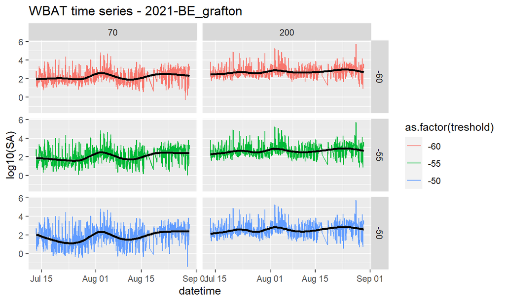

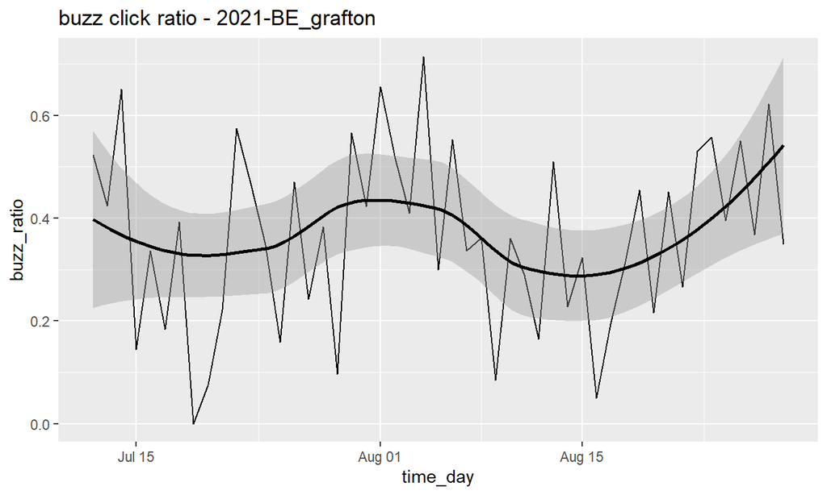

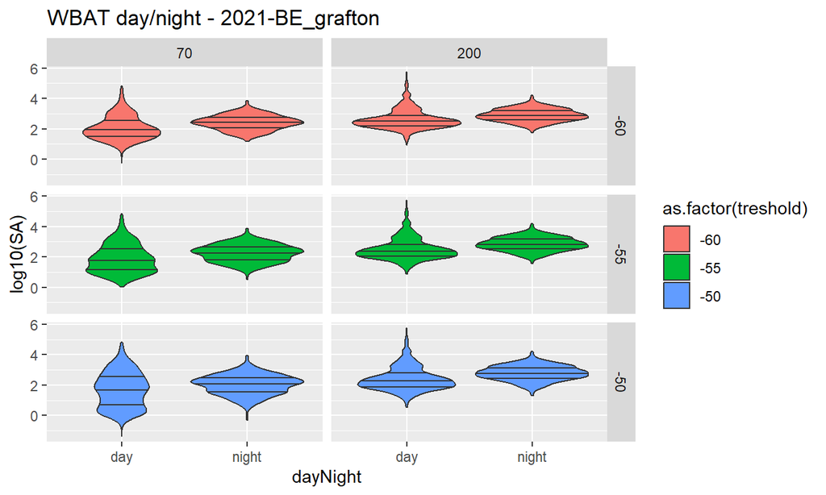

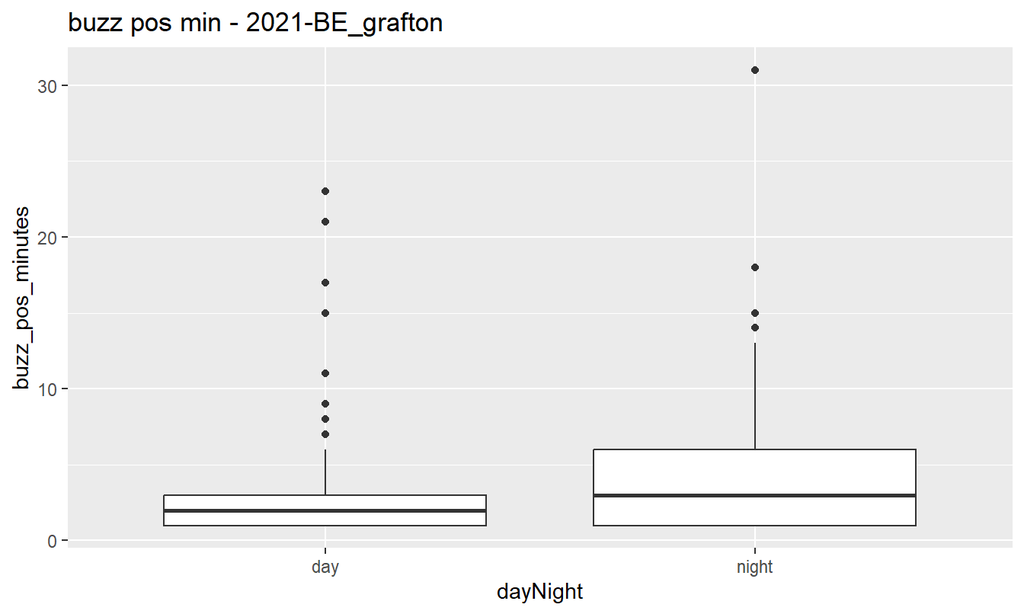

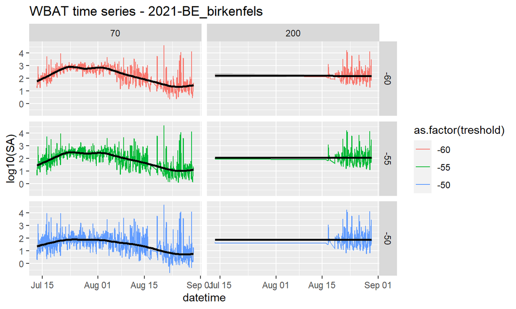

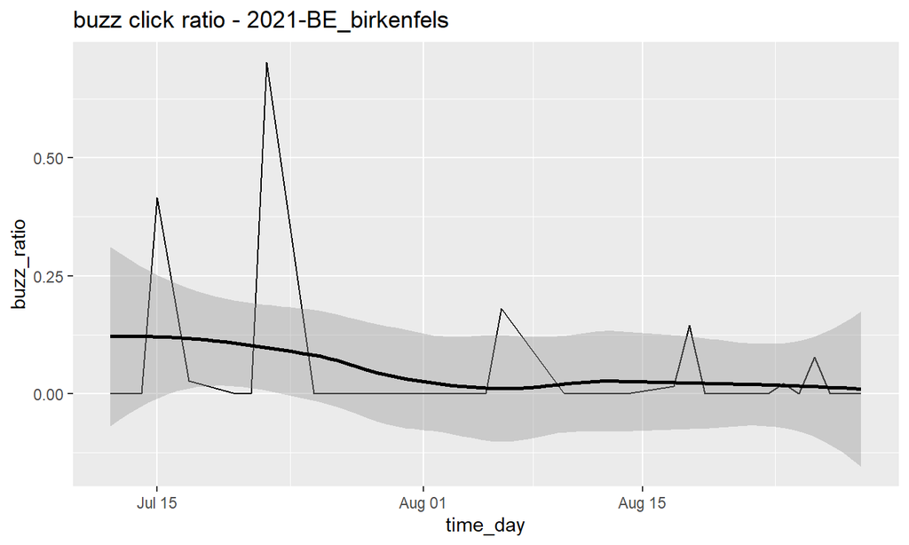

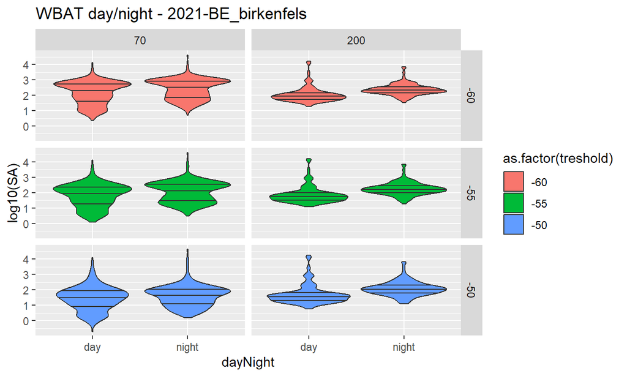

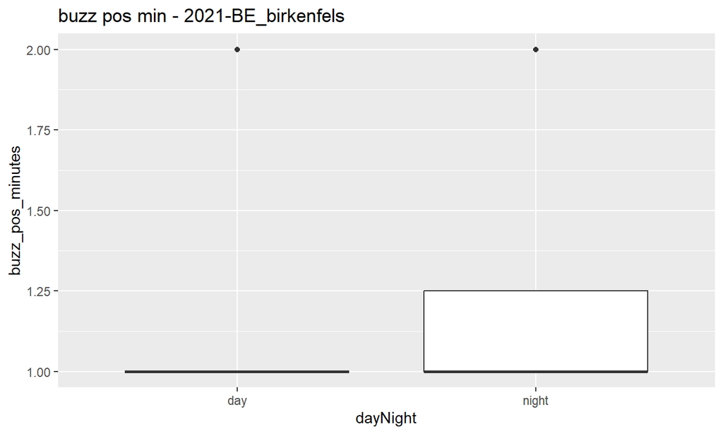

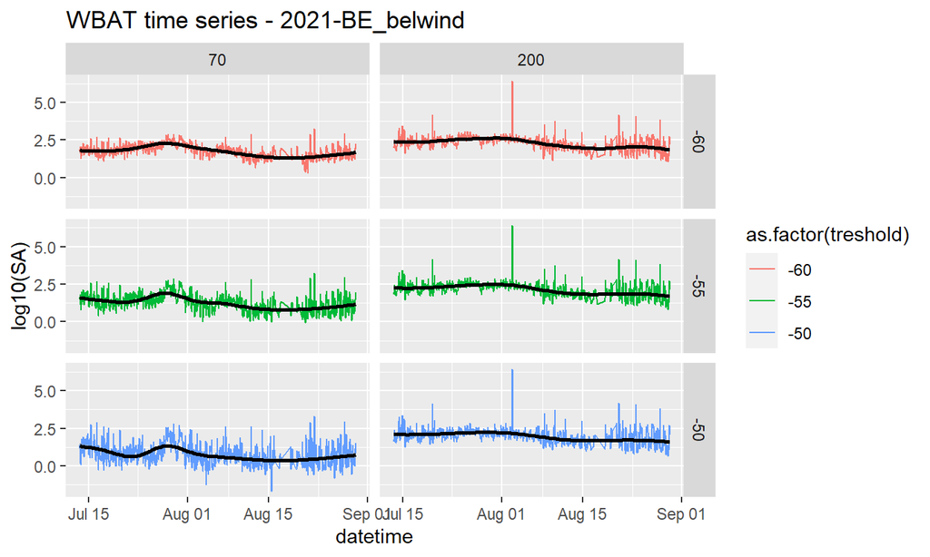

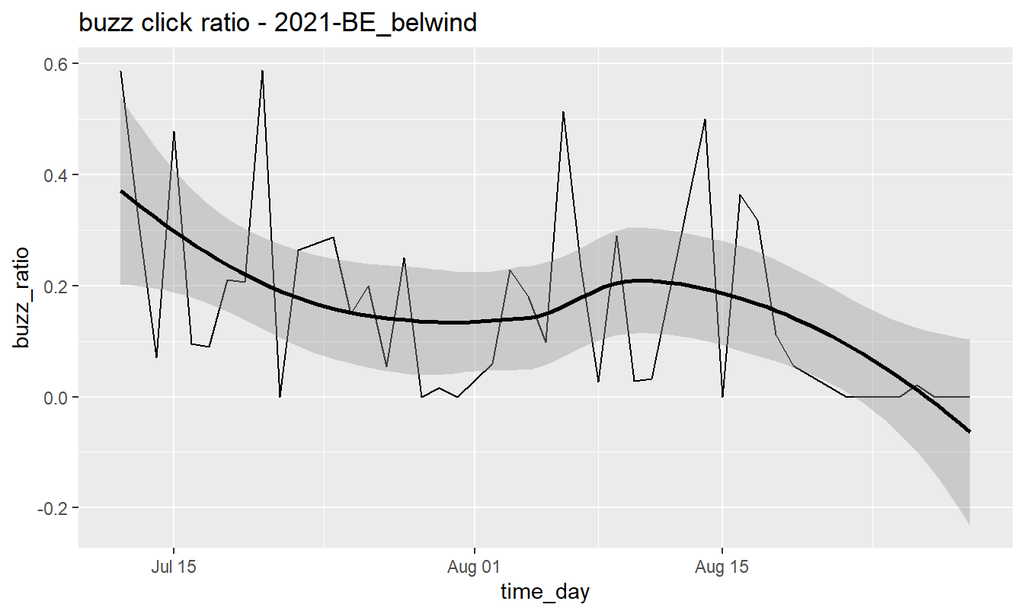

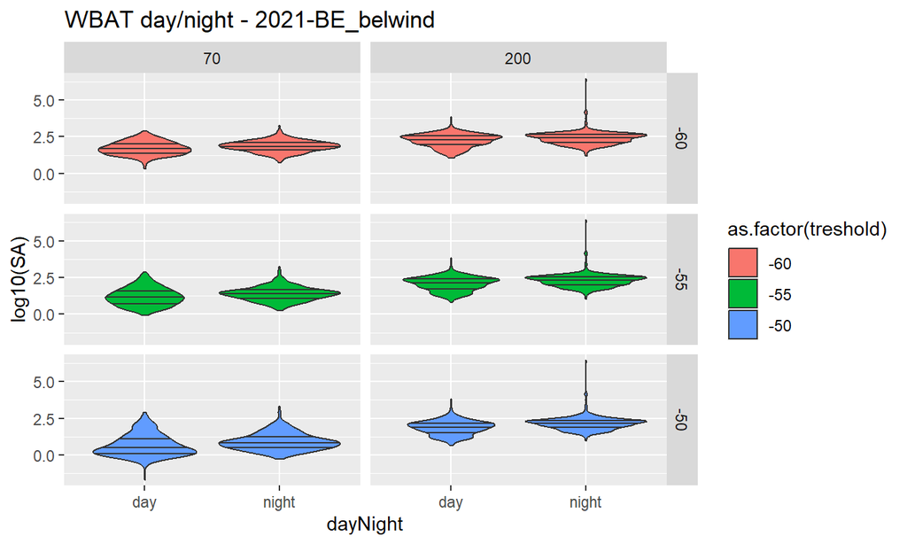

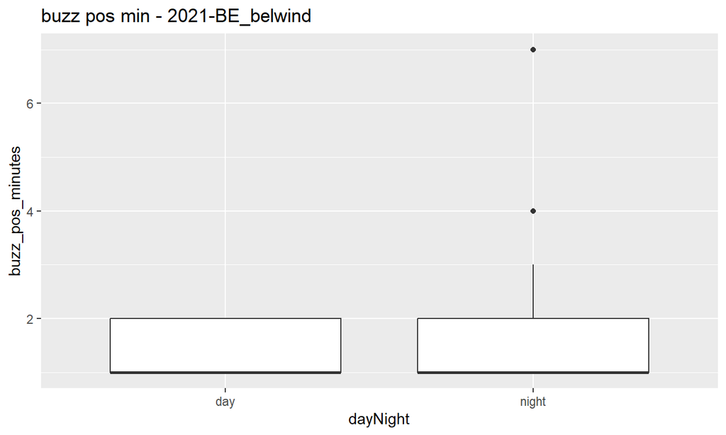

[58 more figures not shown]

**Figure 2.2. CPOD/WBAT results per station.**

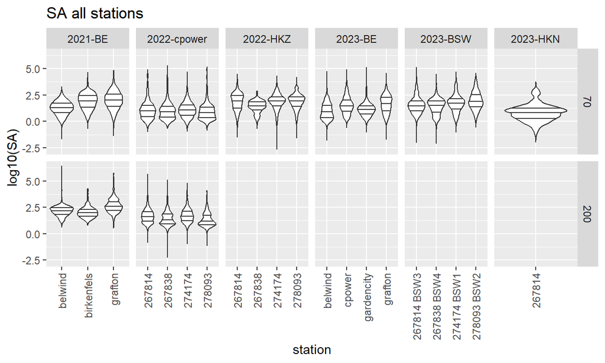

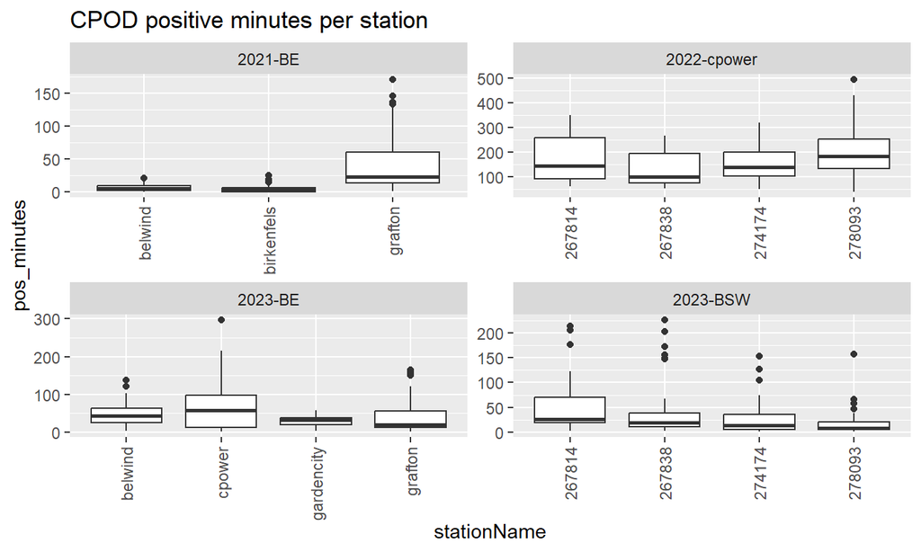

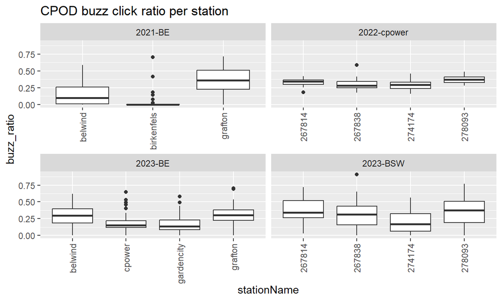

**Figure 2.3. CPOD/WBAT correlation.**

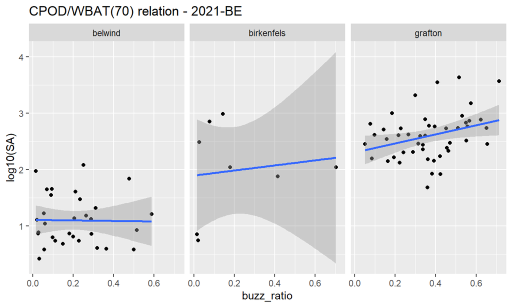

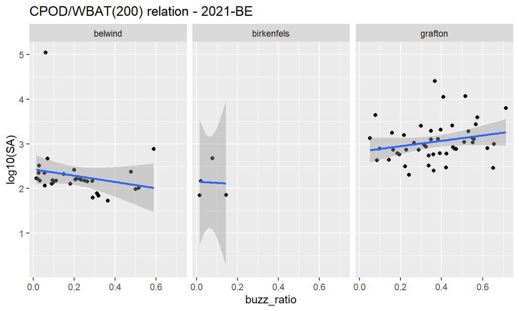

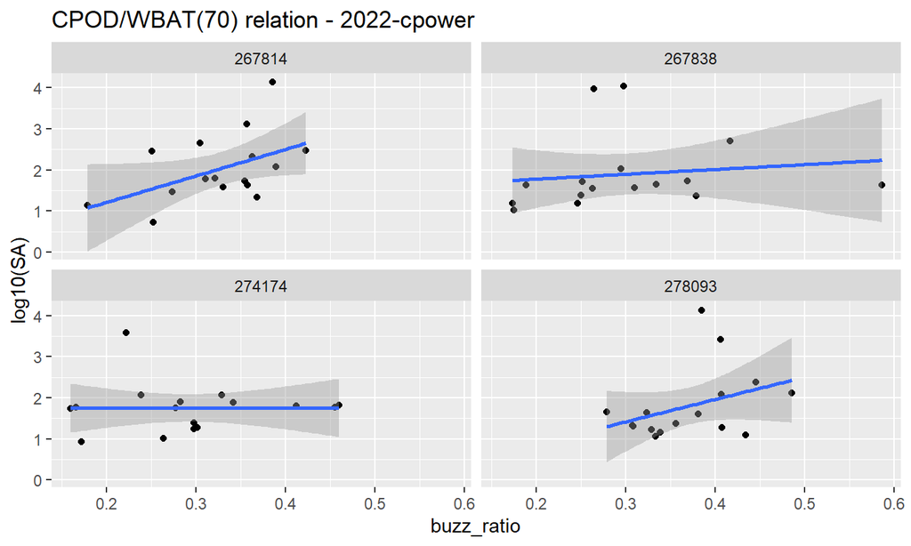

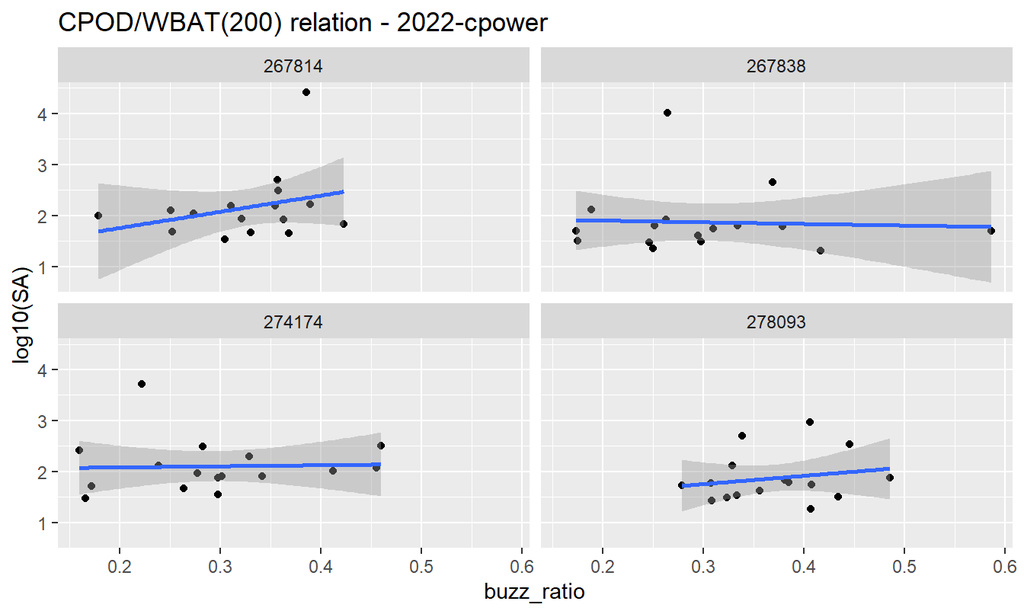

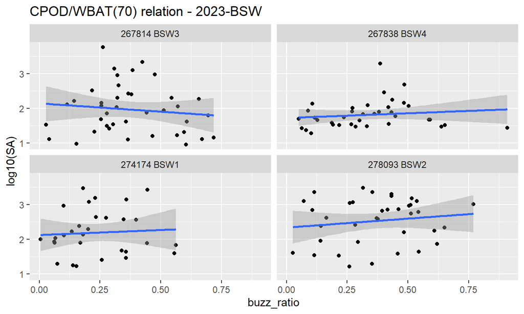

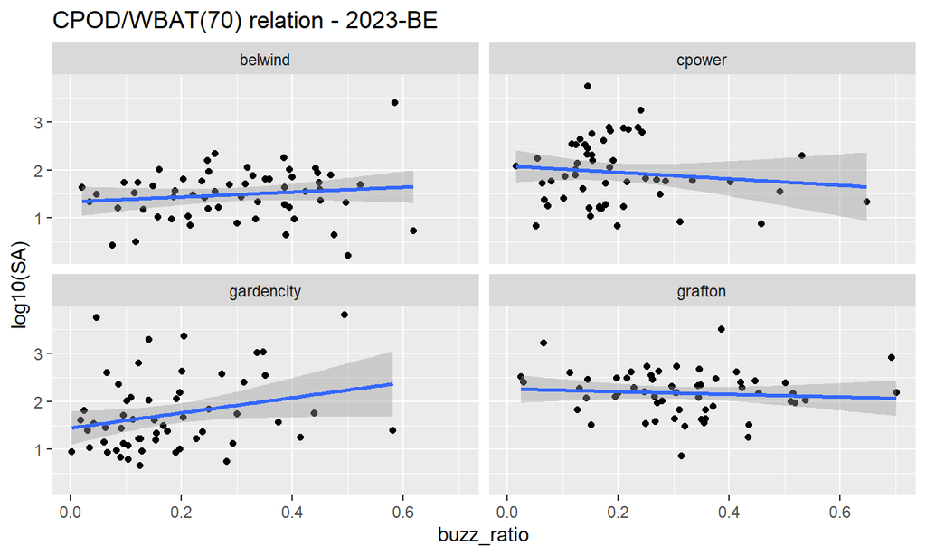